# Lab 5

Team:  
Mitchell Morrison  
Kyle Kolodziej  
Brian Pattison  
Sam Yassien

Our dataset from kaggle (https://www.kaggle.com/fedesoriano/stroke-prediction-dataset) is intended to be used for stroke prediction. The dataset contains 5000 instances and 11 feature columns and one target attribute, high liklihood of stroke. Our dataset is highly imbalanced in our stroke feature column and is split 95/5% 0 (not likely): 1 (very likely) of a stroke event. To prevent our model from overestimating that someone is unlikely for stroke we will upsampled our training data. The data contains clearly relevant features to stroke prediction such as age, gender, hypertension, heart disease, glucose level, bmi, and smoking history. However, we have additional interesting categorical features that may influence stroke likelihood as well such as ever married, work type, and residence type. We use all of these features and add a wide network to our models for memorization of common cross column encoded data.

```python
import pandas as pd
import numpy as np
import seaborn as sns
import matplotlib
import matplotlib.pyplot as plt
import warnings
from sklearn.metrics import accuracy_score
from sklearn.model_selection import train_test_split
from sklearn.preprocessing import LabelEncoder
from sklearn.preprocessing import StandardScaler
from sklearn import metrics as mt
from tensorflow import keras
from tensorflow.keras.layers import Dense, Activation, Input
from tensorflow.keras.layers import Embedding, Flatten, Concatenate
from tensorflow.keras.models import Model
from tensorflow.keras.layers import Embedding
from tensorflow.keras.layers import concatenate
import tensorflow as tf
from sklearn.metrics import confusion_matrix, ConfusionMatrixDisplay
from sklearn import metrics as mt
```

```python
df = pd.read_csv('../../healthcare-dataset-stroke-data.csv')
df.head()
```

|  | id | gender | age | hypertension | heart_disease | ever_married | work_type | Residence_type | avg_glucose_level | bmi | smoking_status | stroke |
| --- | --- | --- | --- | --- | --- | --- | --- | --- | --- | --- | --- | --- |
| 0 | 9046 | Male | 67.0 | 0 | 1 | Yes | Private | Urban | 228.69 | 36.6 | formerly smoked | 1 |
| 1 | 51676 | Female | 61.0 | 0 | 0 | Yes | Self-employed | Rural | 202.21 | NaN | never smoked | 1 |
| 2 | 31112 | Male | 80.0 | 0 | 1 | Yes | Private | Rural | 105.92 | 32.5 | never smoked | 1 |
| 3 | 60182 | Female | 49.0 | 0 | 0 | Yes | Private | Urban | 171.23 | 34.4 | smokes | 1 |
| 4 | 1665 | Female | 79.0 | 1 | 0 | Yes | Self-employed | Rural | 174.12 | 24.0 | never smoked | 1 |

```python
df = df.dropna()
df=df.drop(['id'], axis=1)
df.info()
```

```
<class 'pandas.core.frame.DataFrame'>
Int64Index: 4909 entries, 0 to 5109
Data columns (total 11 columns):
gender               4909 non-null object
age                  4909 non-null float64
hypertension         4909 non-null int64
heart_disease        4909 non-null int64
ever_married         4909 non-null object
work_type            4909 non-null object
Residence_type       4909 non-null object
avg_glucose_level    4909 non-null float64
bmi                  4909 non-null float64
smoking_status       4909 non-null object
stroke               4909 non-null int64
dtypes: float64(3), int64(3), object(5)
memory usage: 460.2+ KB
```

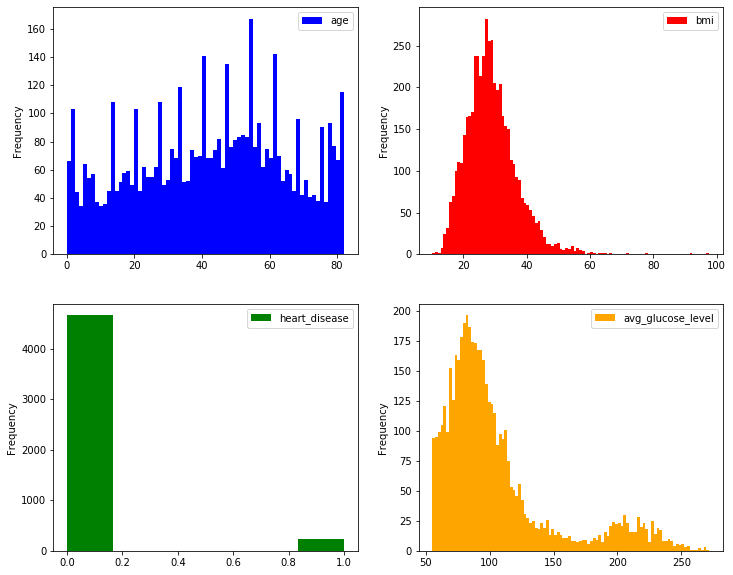

```python
fig, axes = plt.subplots(nrows=2, ncols=2, figsize=(12, 10))
df.plot(kind="hist", y="age", bins=70, color="b", ax=axes[0][0])
df.plot(kind="hist", y="bmi", bins=100, color="r", ax=axes[0][1])
df.plot(kind="hist", y="heart_disease", bins=6, color="g", ax=axes[1][0])
df.plot(kind="hist", y="avg_glucose_level", bins=100, color="orange", ax=axes[1][1])
plt.show()

#Source: https://www.kaggle.com/ahmedterry/stroke-prediction-eda-classification-models
```

In this section below we split the BMI column into different ranges. These ranges are determined by the information given at https://www.cdc.gov/healthyweight/assessing/bmi/adult_bmi/index.html#InterpretedAdults which provides information about adult BMI ranges with expert domain knowledge. We did this split to help use cross columns on numerical data such as BMI. Although there is some amount of data which is not adults, the difference between the scales is small enough that classifying all rows as adults is reasonable.

```python
df['bmi_range'] = pd.cut(df['bmi'],[0,18.5,24.9,29.5, 1e5],
            labels=['Underweight','Healthy','Overweight', 'Obese'])
```

```python
df.info()
```

```
<class 'pandas.core.frame.DataFrame'>
Int64Index: 4909 entries, 0 to 5109
Data columns (total 12 columns):
gender               4909 non-null object
age                  4909 non-null float64
hypertension         4909 non-null int64
heart_disease        4909 non-null int64
ever_married         4909 non-null object
work_type            4909 non-null object
Residence_type       4909 non-null object
avg_glucose_level    4909 non-null float64
bmi                  4909 non-null float64
smoking_status       4909 non-null object
stroke               4909 non-null int64
bmi_range            4909 non-null category
dtypes: category(1), float64(3), int64(3), object(5)
memory usage: 465.2+ KB
```

```python
df.head()
```

|  | gender | age | hypertension | heart_disease | ever_married | work_type | Residence_type | avg_glucose_level | bmi | smoking_status | stroke | bmi_range |
| --- | --- | --- | --- | --- | --- | --- | --- | --- | --- | --- | --- | --- |
| 0 | Male | 67.0 | 0 | 1 | Yes | Private | Urban | 228.69 | 36.6 | formerly smoked | 1 | Obese |
| 2 | Male | 80.0 | 0 | 1 | Yes | Private | Rural | 105.92 | 32.5 | never smoked | 1 | Obese |
| 3 | Female | 49.0 | 0 | 0 | Yes | Private | Urban | 171.23 | 34.4 | smokes | 1 | Obese |
| 4 | Female | 79.0 | 1 | 0 | Yes | Self-employed | Rural | 174.12 | 24.0 | never smoked | 1 | Healthy |
| 5 | Male | 81.0 | 0 | 0 | Yes | Private | Urban | 186.21 | 29.0 | formerly smoked | 1 | Overweight |

```python
encoders = dict()
# male: 1 female: 0
# rural: 1 urban: 0
# married_yes: 1 married_no: 0

if df.gender.dtype=='object':
    df.gender.replace(to_replace=['Male','Female', 'Other'],value=[1,0, 2],inplace=True)

if df.Residence_type.dtype=='object':
    df.Residence_type.replace(to_replace=['Rural','Urban'],value=[1,0],inplace=True)

if df.ever_married.dtype=='object':
    df.ever_married.replace(to_replace=['Yes','No'],value=[1,0],inplace=True)

df.head()
```

|  | gender | age | hypertension | heart_disease | ever_married | work_type | Residence_type | avg_glucose_level | bmi | smoking_status | stroke | bmi_range |
| --- | --- | --- | --- | --- | --- | --- | --- | --- | --- | --- | --- | --- |
| 0 | 1 | 67.0 | 0 | 1 | 1 | Private | 0 | 228.69 | 36.6 | formerly smoked | 1 | Obese |
| 2 | 1 | 80.0 | 0 | 1 | 1 | Private | 1 | 105.92 | 32.5 | never smoked | 1 | Obese |
| 3 | 0 | 49.0 | 0 | 0 | 1 | Private | 0 | 171.23 | 34.4 | smokes | 1 | Obese |
| 4 | 0 | 79.0 | 1 | 0 | 1 | Self-employed | 1 | 174.12 | 24.0 | never smoked | 1 | Healthy |
| 5 | 1 | 81.0 | 0 | 0 | 1 | Private | 0 | 186.21 | 29.0 | formerly smoked | 1 | Overweight |

```python
categorical_headers = ['work_type',
                       'smoking_status', 'bmi_range']

for col in categorical_headers:
    df[col] = df[col].str.strip()

    encoders[col] = LabelEncoder() # save the encoder
    df[col+'_int'] = encoders[col].fit_transform(df[col])
df.head()
```

|  | gender | age | hypertension | heart_disease | ever_married | work_type | Residence_type | avg_glucose_level | bmi | smoking_status | stroke | bmi_range | work_type_int | smoking_status_int | bmi_range_int |
| --- | --- | --- | --- | --- | --- | --- | --- | --- | --- | --- | --- | --- | --- | --- | --- |
| 0 | 1 | 67.0 | 0 | 1 | 1 | Private | 0 | 228.69 | 36.6 | formerly smoked | 1 | Obese | 2 | 1 | 1 |
| 2 | 1 | 80.0 | 0 | 1 | 1 | Private | 1 | 105.92 | 32.5 | never smoked | 1 | Obese | 2 | 2 | 1 |
| 3 | 0 | 49.0 | 0 | 0 | 1 | Private | 0 | 171.23 | 34.4 | smokes | 1 | Obese | 2 | 3 | 1 |
| 4 | 0 | 79.0 | 1 | 0 | 1 | Self-employed | 1 | 174.12 | 24.0 | never smoked | 1 | Healthy | 3 | 2 | 0 |
| 5 | 1 | 81.0 | 0 | 0 | 1 | Private | 0 | 186.21 | 29.0 | formerly smoked | 1 | Overweight | 2 | 1 | 2 |

```python
df = df.reindex(columns=['gender','age','hypertension','heart_disease', 'ever_married', 'work_type', 'Residence_type', 'avg_glucose_level','bmi', 'smoking_status', 'stroke', 'bmi_range', 'work_type_int', 'smoking_status_int', 'bmi_range_int'])
df.head()
```

|  | gender | age | hypertension | heart_disease | ever_married | work_type | Residence_type | avg_glucose_level | bmi | smoking_status | stroke | bmi_range | work_type_int | smoking_status_int | bmi_range_int |
| --- | --- | --- | --- | --- | --- | --- | --- | --- | --- | --- | --- | --- | --- | --- | --- |
| 0 | 1 | 67.0 | 0 | 1 | 1 | Private | 0 | 228.69 | 36.6 | formerly smoked | 1 | Obese | 2 | 1 | 1 |
| 2 | 1 | 80.0 | 0 | 1 | 1 | Private | 1 | 105.92 | 32.5 | never smoked | 1 | Obese | 2 | 2 | 1 |
| 3 | 0 | 49.0 | 0 | 0 | 1 | Private | 0 | 171.23 | 34.4 | smokes | 1 | Obese | 2 | 3 | 1 |
| 4 | 0 | 79.0 | 1 | 0 | 1 | Self-employed | 1 | 174.12 | 24.0 | never smoked | 1 | Healthy | 3 | 2 | 0 |
| 5 | 1 | 81.0 | 0 | 0 | 1 | Private | 0 | 186.21 | 29.0 | formerly smoked | 1 | Overweight | 2 | 1 | 2 |

The final dataset we are using has 15 total columns, three of which are categorical columns. The ID column was deleted at the beginning because it has no use for classification. The age, bmi, and avg_glucose_level columns will be normalized after our test-train split.

```python
from imblearn.over_sampling import SMOTE
```

```python
##### visualization class for dimension reduction and plotting result
from sklearn.decomposition import PCA
class sampling():

    def __init__(self,feat,tar,method,ax):
        self.feat = feat
        self.tar = tar
        self.method = method
        self.ax = ax


    # under sampling visualization

    def visualize_data(self):

        temp_y = pd.DataFrame({'y':self.tar})

        # dimension reduction
        pca = PCA(n_components= 2).fit_transform(self.feat)

        self.ax.set_facecolor('#f5f6f6')
        # plotting4
        self.ax.scatter(pca[temp_y['y'] == 0][:,0], pca[temp_y['y'] == 0][:,1], c = '#512b58', s = 10)
        self.ax.scatter(pca[temp_y['y'] == 1][:,0], pca[temp_y['y'] == 1][:,1], c = '#ff005c', s =10)

        for loc in ['left','right','top', 'bottom']:
            self.ax.spines[loc].set_visible(False)
        self.ax.axes.get_xaxis().set_visible(False)
        self.ax.axes.get_yaxis().set_visible(False)
        self.ax.set_xticklabels('')
        self.ax.set_yticklabels('')
        self.ax.set_xlim(xmin = -6, xmax = 6)
        self.ax.set_ylim(ymin = -5, ymax = 6)


        self.ax.text(1.6,3.8,"Stroke", fontweight="bold", fontfamily='serif', fontsize=13, color='#ff005c')
        self.ax.text(3.2,3.8,"|", fontweight="bold", fontfamily='serif', fontsize=13, color='black')
        self.ax.text(3.4,3.8,"No stroke", fontweight="bold", fontfamily='serif', fontsize=13, color='#512b58')
        self.ax.text(-6,5.5,self.method, alpha = 0.8)
        self.ax.text(-6,4.5,'{} contain {} number of datapoint, \nand targets distribution as blank.'.format(self.method,len(self.feat)), alpha = 0.7)
```

**SMOTE Oversampling**</br>

Drawbacks of oversampling: if you have classes with very few instances you might put too much emphasis on the fact that those samples belong to a specific class.

Benefits: Providing our model with a balanced daatset will allow it to properly learn how to differentiate those with strokes from others without the model reflecting many more non-stroke predictions just because we had few stroke samples.

Drawbacks source: https://www.machinecurve.com/index.php/2020/11/10/working-with-imbalanced-datasets-with-tensorflow-and-keras/

**Splitting our data**

```python
oversample = SMOTE()
df_test = df[['gender','age','hypertension','heart_disease', 'ever_married', 'Residence_type', 'avg_glucose_level','bmi', 'stroke', 'work_type_int', 'smoking_status_int', 'bmi_range_int']].sample(int(df.shape[0]*0.2),random_state=42)

df_noLabel = df[['gender','age','hypertension','heart_disease', 'ever_married', 'Residence_type', 'avg_glucose_level','bmi', 'stroke', 'work_type_int', 'smoking_status_int', 'bmi_range_int']]

df_train = df_noLabel.drop(index=df_test.index)
```

```python
df_train.info()
```

```
<class 'pandas.core.frame.DataFrame'>
Int64Index: 3928 entries, 0 to 5109
Data columns (total 12 columns):
gender                3928 non-null int64
age                   3928 non-null float64
hypertension          3928 non-null int64
heart_disease         3928 non-null int64
ever_married          3928 non-null int64
Residence_type        3928 non-null int64
avg_glucose_level     3928 non-null float64
bmi                   3928 non-null float64
stroke                3928 non-null int64
work_type_int         3928 non-null int32
smoking_status_int    3928 non-null int32
bmi_range_int         3928 non-null int32
dtypes: float64(3), int32(3), int64(6)
memory usage: 352.9 KB
```

```python
df_test.info()
```

```
<class 'pandas.core.frame.DataFrame'>
Int64Index: 981 entries, 4336 to 5010
Data columns (total 12 columns):
gender                981 non-null int64
age                   981 non-null float64
hypertension          981 non-null int64
heart_disease         981 non-null int64
ever_married          981 non-null int64
Residence_type        981 non-null int64
avg_glucose_level     981 non-null float64
bmi                   981 non-null float64
stroke                981 non-null int64
work_type_int         981 non-null int32
smoking_status_int    981 non-null int32
bmi_range_int         981 non-null int32
dtypes: float64(3), int32(3), int64(6)
memory usage: 88.1 KB
```

```python
numeric_headers = ["age", "bmi", "avg_glucose_level"]

for col in numeric_headers:
    df_test[col] = df_test[col].astype(np.float)
    df_train[col] = df_train[col].astype(np.float)

    ss = StandardScaler()
    df_test[col] = ss.fit_transform(df_test[col].values.reshape(-1, 1))
    df_train[col] = ss.fit_transform(df_train[col].values.reshape(-1, 1))

df_test.head()
```

|  | gender | age | hypertension | heart_disease | ever_married | Residence_type | avg_glucose_level | bmi | stroke | work_type_int | smoking_status_int | bmi_range_int |
| --- | --- | --- | --- | --- | --- | --- | --- | --- | --- | --- | --- | --- |
| 4336 | 1 | 1.612299 | 0 | 1 | 1 | 1 | 0.446818 | 0.461169 | 0 | 2 | 0 | 1 |
| 3709 | 0 | -0.056137 | 0 | 0 | 0 | 0 | -0.479348 | 0.278003 | 0 | 2 | 2 | 1 |
| 964 | 1 | 0.997612 | 1 | 0 | 1 | 1 | -0.684141 | 0.363481 | 0 | 2 | 2 | 1 |
| 2647 | 1 | -0.626918 | 0 | 0 | 1 | 0 | -0.067295 | -0.271493 | 0 | 0 | 3 | 2 |
| 3262 | 1 | 0.163394 | 0 | 0 | 1 | 1 | -0.379307 | -0.845412 | 0 | 2 | 3 | 0 |

```python
df_train.head()
```

|  | gender | age | hypertension | heart_disease | ever_married | Residence_type | avg_glucose_level | bmi | stroke | work_type_int | smoking_status_int | bmi_range_int |
| --- | --- | --- | --- | --- | --- | --- | --- | --- | --- | --- | --- | --- |
| 0 | 1 | 1.077447 | 0 | 1 | 1 | 0 | 2.780770 | 0.999771 | 1 | 2 | 1 | 1 |
| 2 | 1 | 1.655338 | 0 | 1 | 1 | 1 | 0.014389 | 0.471829 | 1 | 2 | 2 | 1 |
| 3 | 0 | 0.277291 | 0 | 0 | 1 | 0 | 1.486022 | 0.716485 | 1 | 2 | 3 | 1 |
| 4 | 0 | 1.610885 | 1 | 0 | 1 | 1 | 1.551142 | -0.622684 | 1 | 3 | 2 | 0 |
| 5 | 1 | 1.699791 | 0 | 0 | 1 | 0 | 1.823567 | 0.021147 | 1 | 2 | 1 | 2 |

```python
test_X = df_test[['gender','age','hypertension','heart_disease', 'ever_married', 'Residence_type', 'avg_glucose_level','bmi', 'stroke',
                  'work_type_int', 'smoking_status_int', 'bmi_range_int']]
y_test = df_test['stroke']

X = df_train[['gender','age','hypertension','heart_disease', 'ever_married', 'Residence_type', 'avg_glucose_level','bmi', 'stroke',
                  'work_type_int', 'smoking_status_int', 'bmi_range_int']]
y = df_train['stroke']

X, y = oversample.fit_resample(X,y)
usampled_df = X.assign(Stroke = y)

# test_X,test_y = oversample.fit_resample(test_X,test_y)
# usampled_eval_df = test_X.assign(Stroke = test_y)
```

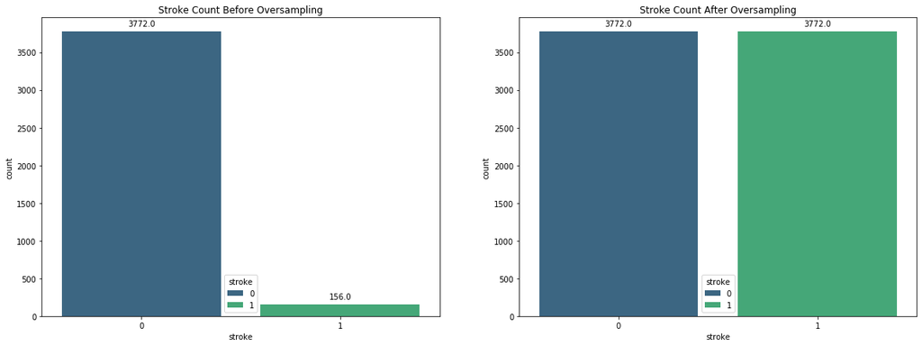

```python
#Source for visualization below:
#https://www.kaggle.com/abtabm/indepth-stroke-analysis-eda-smote-91-acc?scriptVersionId=59580703&cellId=46

ax = plt.subplots(figsize=(20,7))
plt.subplot(1,2,1)
ax=sns.countplot('stroke', data=pd.DataFrame(df_train), palette='viridis',hue="stroke",dodge=False)
plt.title("Stroke Count Before Oversampling")
for p in ax.patches:
    ax.annotate((p.get_height()), (p.get_x() + p.get_width() / 2., p.get_height()), ha = 'center', va = 'center', xytext = (0, 10), textcoords = 'offset points')

from imblearn.over_sampling import SMOTE
samp = SMOTE(random_state=3)
#X_train, y_train = samp.fit_resample(X_train, y_train.ravel())

plt.subplot(1,2,2)
ax=sns.countplot('stroke', data=pd.DataFrame(y), palette='viridis',hue="stroke",dodge=False)
plt.title("Stroke Count After Oversampling")
for p in ax.patches:
    ax.annotate((p.get_height()), (p.get_x() + p.get_width() / 2., p.get_height()), ha = 'center', va = 'center', xytext = (0, 10), textcoords = 'offset points')
```

Here is a visual that shows how the data set has been augmented into a balanced data set

```python
X.head()
```

|  | gender | age | hypertension | heart_disease | ever_married | Residence_type | avg_glucose_level | bmi | stroke | work_type_int | smoking_status_int | bmi_range_int |
| --- | --- | --- | --- | --- | --- | --- | --- | --- | --- | --- | --- | --- |
| 0 | 1 | 1.077447 | 0 | 1 | 1 | 0 | 2.780770 | 0.999771 | 1 | 2 | 1 | 1 |
| 1 | 1 | 1.655338 | 0 | 1 | 1 | 1 | 0.014389 | 0.471829 | 1 | 2 | 2 | 1 |
| 2 | 0 | 0.277291 | 0 | 0 | 1 | 0 | 1.486022 | 0.716485 | 1 | 2 | 3 | 1 |
| 3 | 0 | 1.610885 | 1 | 0 | 1 | 1 | 1.551142 | -0.622684 | 1 | 3 | 2 | 0 |
| 4 | 1 | 1.699791 | 0 | 0 | 1 | 0 | 1.823567 | 0.021147 | 1 | 2 | 1 | 2 |

## Final Datasets

```python
cross_columns = [['hypertension','heart_disease', 'smoking_status_int'],
                 ['ever_married','work_type_int', 'gender'],
                ['bmi_range_int', 'heart_disease'],
                   ['bmi_range_int', 'gender']]
cross_col_df_names = []
for cols_list in cross_columns:
    # encode as ints for the embedding
    enc = LabelEncoder()

    # 1. create crossed labels by join operation
    X_crossed_train = X[cols_list].apply(lambda x: '_'.join(str(x)), axis=1)
    X_crossed_test = test_X[cols_list].apply(lambda x: '_'.join(str(x)), axis=1)

    # get a nice name for this new crossed column
    cross_col_name = '_'.join(cols_list)

    # 2. encode as integers
    enc.fit(np.hstack((X_crossed_train.to_numpy(),  X_crossed_test.to_numpy())))

    # 3. Save into dataframe with new name
    X[cross_col_name] = enc.transform(X_crossed_train)
    test_X[cross_col_name] = enc.transform(X_crossed_test)

    # keep track of the new names of the crossed columns
    cross_col_df_names.append(cross_col_name)

cross_col_df_names
```

```
['hypertension_heart_disease_smoking_status_int',
 'ever_married_work_type_int_gender',
 'bmi_range_int_heart_disease',
 'bmi_range_int_gender']
```

The output above shows all of the cross columns we have created for our dataset. Hopkins Medical School published storke risk factors and listed heart disease, gender, and smoking as major risks. Those attributes are present in this dataset and have significant correlations to increased risk of stroke when an individual has multiple high risk factors.

A study published on Circulation Research from 2017 states the following, “The investigators enrolled 3000 patients with stroke and found that hypertension, current smoking, waist-to-hip ratio, diet risk score, regular physical activity, diabetes mellitus, binge alcohol consumption and psychosocial stress and depression were all associated with stroke risk.” (1) They also highlight that a combination of these stroke risk factors continutes to increase stroke risk. This indicates that combining high risk factors could help improve our model by giving Wide branches to use memorization.

The first group we decided to combine was hypertension, heart_disease and smoking_status_int. We decied to combine these together because they are all high risk stroke factors from these studies and significant research points to their compunding effect on increasing stroke risk (2).

The second set of cross columns is ever_married, work_type_int and gender. Because personal life and stress can be attributed to things like hemmoraging and high stress, it is a valuable reason to consider work and marriage as major stressors. We also are interested in gender in this particular cross column because it is a major consideration in marraige and could help separate some specific cases of high stroke risk.

The third set of cross columns is bmi_range_int and heart_disease. We decided these were fitting to combine because while heart disease is a cause of stroke, obesity can often be a cause of both heart disease and strokes and both are immediate health risks if at extreme levels (3). We believe this potential overlap in these two columns could help our wide network see a relationship between having high BMI levels and heart disease and more obviously low risk individuals who are not at high BMI and don’t ave heart disease. Although we want to understnad what causes stoke, seeing what attributes with low levels or certain combinations that do not commonly lead to strokes are also valuable information.

The last cross product was to combine gender and bmi_range_int because frankly a team member has a hunch that overweight men are more likely to have strokes than overweight women.

Splitting our BMI feature into categories classified by expert knowledge and the scientific community helps us add an additioanl level of knowledge and reason to splitting the feature a certain way and allows us to nearly cross categorical columns with ranged numeric data.

(1) - https://www.ahajournals.org/doi/full/10.1161/circresaha.116.308398  
(2) - https://www.heartandstroke.ca/healthy-living/reduce-stress/stress-basics#:~:text=Stress%20can%20cause%20the%20heart,a%20heart%20attack%20or%20stroke  
(3) - https://www.webmd.com/stroke/guide/stroke-causes-risks#2 </br>

## Validation

In our prediction task, it is extremely important to remember exactly what the implications of our model could mean - if we predict someone to not be at risk of stroke when they truly are, we could be putting someone’s life at risk. For this reason, we must focus on improving our false negatives scores and attempt to minimize false negatives to as close to 0 instances as possible.

Looking at other metrics, we are OK with having high false positives in our algorithm as long as it means the false negatives are low. Meaning, if we overpredict the risk of stroke feature to be true (1), then we will be more likely to meet our condition of minimizing false negatives. However, like most trade offs, we are not planning to use this caveot to predict all individuals as high risk, as that would largely defeat the purpose of the algorithm and potentially give people stress (doctor tells you you’re at risk for stroke, when you may not actually be, doesn’t that freak you out? Maybe cause you stress you didn’t need?).

Right now, only 4% of our dataset is at risk of a stroke. That means that achieving a high accuracy would be very easy. If you were to predict everybody as not at risk for a stroke then the accuracy would be about 96%. That is why our main focus is not accuracy, but rather minimizing any false negatives. Given these conditions for what we need to minimize, we will largely base our performance on the Recall of predicting class 1 in stroke prediction, attempting to maximize this value and bring it as close to 1.00 as possible (this is really just (1 - Type II error). Additionally, since measuring recall of both of the 2 predition classes (0 or 1) in essence is a reflection of accuracy, we will also use accuracy as a metric for performance in our classifier, behind Recall of prediction class 1.

## Splitting our Data and Cross Validation Method

Before upsampling our data, it is important to split the dataset into testing and training data so we do not interfere with the validation set before running models and using minority upsampling to increase the amount of stroke instance features in our training data.

For the majority of the program / lab, we will have split our data using the pandas .sample() function to take our input df and return 20% randomly selected. This serves as our validation set for most of the lab.

However, we feel that the best method to truly train and optmize our model would be to use 5-fold cross validation testing. By using this form of validation, our model is training on a (slightly) new dataset and verifying the model on a new set of testing data (that was or will be used for training as well). This cross validation ensures that every observation from the original dataset has the chance of appearing in training and test set. Additionally, it works well for training and testing models with smaller datasets (as this data set has less than 10,000 instances). Although we are not using the 5-fold cross validation for each model in the lab, we will use it later in the lab. First, we will use cross validation on models with varying numbers of layers. This will help us determine which model performs the best. After getting this "best performing model", we will compare it to the MLP, again using the 5-fold cross validation on the MLP as another way to compare their perfomance.

```python
test_X.info()
```

```
<class 'pandas.core.frame.DataFrame'>
Int64Index: 981 entries, 4336 to 5010
Data columns (total 16 columns):
gender                                           981 non-null int64
age                                              981 non-null float64
hypertension                                     981 non-null int64
heart_disease                                    981 non-null int64
ever_married                                     981 non-null int64
Residence_type                                   981 non-null int64
avg_glucose_level                                981 non-null float64
bmi                                              981 non-null float64
stroke                                           981 non-null int64
work_type_int                                    981 non-null int32
smoking_status_int                               981 non-null int32
bmi_range_int                                    981 non-null int32
hypertension_heart_disease_smoking_status_int    981 non-null int32
ever_married_work_type_int_gender                981 non-null int32
bmi_range_int_heart_disease                      981 non-null int32
bmi_range_int_gender                             981 non-null int32
dtypes: float64(3), int32(7), int64(6)
memory usage: 103.5 KB
```

```
[[467 461]
 [ 29  24]]
              precision    recall  f1-score   support

           0       0.94      0.50      0.66       928
           1       0.05      0.45      0.09        53

    accuracy                           0.50       981
   macro avg       0.50      0.48      0.37       981
weighted avg       0.89      0.50      0.63       981
```

```
<sklearn.metrics._plot.confusion_matrix.ConfusionMatrixDisplay at 0x29fdcf13d08>
```

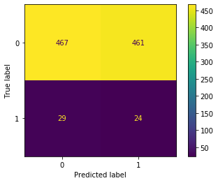

```python
X_crossed_train = X[cross_col_df_names].to_numpy()
X_crossed_test = test_X[cross_col_df_names].to_numpy()

crossed_outputs = [] # this is where we will keep track of output of each branch

input_crossed = Input(shape=(X_crossed_train.shape[1],), dtype='int64', name='categorical')
for idx,col in enumerate(cross_col_df_names):

    # track what the maximum integer value will be for this variable
    # which is the same as the number of categories
    N = max(X[col].max(),test_X[col].max())+1

    # this line of code does this: input_branch[:,idx]
    x = tf.gather(input_crossed, idx, axis=1)

    # now use an embedding to deal with integers as if they were one hot encoded
    x = Embedding(input_dim=N,
                  output_dim=int(np.sqrt(N)),
                  input_length=1, name=col+'_embed')(x)

    # save these outputs to concatenate later
    crossed_outputs.append(x)


# now concatenate the outputs and add a fully connected layer
wide_branch = concatenate(crossed_outputs, name='concat_1')
wide_branch = Dense(units=1,activation='sigmoid', name='combined')(wide_branch)

model = Model(inputs=input_crossed, outputs=wide_branch)

model.compile(optimizer='sgd',
              loss='mean_squared_error',
              metrics=['accuracy'])

model.fit(X_crossed_train,
        y, epochs=10, batch_size=32, verbose=1)

yhat_proba = model.predict(X_crossed_test)
yhat = np.round(yhat_proba)
print(mt.confusion_matrix(y_test,yhat))
print(mt.classification_report(y_test,yhat))

from sklearn.metrics import confusion_matrix, ConfusionMatrixDisplay

classes = [0,1]
cm = mt.confusion_matrix(y_test, yhat, labels=classes)
disp = ConfusionMatrixDisplay(confusion_matrix=cm, display_labels=classes)
disp.plot()
```

```python
categorical_headers_ints = [x+'_int' for x in categorical_headers]

X_train = X[categorical_headers_ints].to_numpy()
X_test = test_X[categorical_headers_ints].to_numpy()

embed_branches = []
all_branch_outputs = [] # this is where we will keep track of output of each branch

# feed in the entire matrix of categircal variables
input_branch = Input(shape=(X_train.shape[1],),
                     dtype='int64',
                     name='categorical')

# for each categorical variable
for idx,col in enumerate(categorical_headers_ints):

    # what the maximum integer value for this variable?
    # which is the same as the number of categories
    N = max(X[col].max(),test_X[col].max())+1

    # this line of code does this: input_branch[:,idx]
    x = tf.gather(input_branch, idx, axis=1)

    # now use an embedding to deal with integers as if they were one hot encoded
    x = Embedding(input_dim=N,
                  output_dim=int(np.sqrt(N)),
                  input_length=1, name=col+'_embed')(x)

    # save these outputs in list to concatenate later
    all_branch_outputs.append(x)

# now concatenate the outputs and add a fully connected layer
final_branch = concatenate(all_branch_outputs, name='concat_1')
final_branch = Dense(units=1,
                     activation='sigmoid',
                     name='combined')(final_branch)

model1 = Model(inputs=input_branch, outputs=final_branch)

model1.compile(optimizer='sgd',
              loss='mean_squared_error',
              metrics=['accuracy'])

model1.summary()
```

```
Model: "model_1"
__________________________________________________________________________________________________
Layer (type)                    Output Shape         Param #     Connected to
==================================================================================================
categorical (InputLayer)        [(None, 3)]          0
__________________________________________________________________________________________________
tf.compat.v1.gather_4 (TFOpLamb (None,)              0           categorical[0][0]
__________________________________________________________________________________________________
tf.compat.v1.gather_5 (TFOpLamb (None,)              0           categorical[0][0]
__________________________________________________________________________________________________
tf.compat.v1.gather_6 (TFOpLamb (None,)              0           categorical[0][0]
__________________________________________________________________________________________________
work_type_int_embed (Embedding) (None, 2)            10          tf.compat.v1.gather_4[0][0]
__________________________________________________________________________________________________
smoking_status_int_embed (Embed (None, 2)            8           tf.compat.v1.gather_5[0][0]
__________________________________________________________________________________________________
bmi_range_int_embed (Embedding) (None, 2)            8           tf.compat.v1.gather_6[0][0]
__________________________________________________________________________________________________
concat_1 (Concatenate)          (None, 6)            0           work_type_int_embed[0][0]
                                                                 smoking_status_int_embed[0][0]
                                                                 bmi_range_int_embed[0][0]
__________________________________________________________________________________________________
combined (Dense)                (None, 1)            7           concat_1[0][0]
==================================================================================================
Total params: 33
Trainable params: 33
Non-trainable params: 0
__________________________________________________________________________________________________
```

```python
# get crossed columns
X_train_crossed = X[cross_col_df_names].to_numpy()
X_test_crossed = test_X[cross_col_df_names].to_numpy()

# save categorical features
X_train_cat = X[categorical_headers_ints].to_numpy()
X_test_cat = test_X[categorical_headers_ints].to_numpy()

# and save off the numeric features
X_train_num =  X[numeric_headers].to_numpy()
X_test_num = test_X[numeric_headers].to_numpy()

classes = [0,1]
```

```python
def runModel(model, optimize, iterations, batchSize):
    model.compile(optimizer=optimize,
              loss='mean_squared_error',
              metrics=['accuracy'])

    # lets also add the history variable to see how we are doing
    # and lets add a validation set to keep track of our progress
    history = model.fit([X_train_crossed,X_train_cat,X_train_num],
                    y,
                    epochs=iterations,
                    batch_size=batchSize,
                    verbose=0,
                    validation_data = ([X_test_crossed,X_test_cat,X_test_num],y_test))
    yhat = np.round(model.predict([X_test_crossed,X_test_cat,X_test_num]))
    acc_mod = mt.accuracy_score(y_test,yhat)
    print("Accuracy: " + str(acc_mod))
    print(mt.confusion_matrix(y_test,yhat))
    print(mt.classification_report(y_test,yhat))
    cm = mt.confusion_matrix(y_test, yhat, labels=classes)
    disp = ConfusionMatrixDisplay(confusion_matrix=cm, display_labels=classes)
    disp.plot()
    plt.figure(figsize=(10,4))
    plt.subplot(2,2,1)
    plt.plot(history.history['accuracy'])

    plt.ylabel('Accuracy %')
    plt.title('Training')
    plt.subplot(2,2,2)
    plt.plot(history.history['val_accuracy'])
    plt.title('Validation')

    plt.subplot(2,2,3)
    plt.plot(history.history['loss'])
    plt.ylabel('Training Loss')
    plt.xlabel('epochs')

    plt.subplot(2,2,4)
    plt.plot(history.history['val_loss'])
    plt.xlabel('epochs')
    return cm, yhat
```

```python
def makeModel(denseUnits, denseActivation, finalActivation):
    # get crossed columns
    X_train_crossed = X[cross_col_df_names].to_numpy()
    X_test_crossed = test_X[cross_col_df_names].to_numpy()

    # save categorical features
    X_train_cat = X[categorical_headers_ints].to_numpy()
    X_test_cat = test_X[categorical_headers_ints].to_numpy()

    # and save off the numeric features
    X_train_num =  X[numeric_headers].to_numpy()
    X_test_num = test_X[numeric_headers].to_numpy()


    # we need to create separate lists for each branch
    crossed_outputs = []

    # CROSSED DATA INPUT
    input_crossed = Input(shape=(X_train_crossed.shape[1],), dtype='int64', name='wide_inputs')
    for idx,col in enumerate(cross_col_df_names):

        # track what the maximum integer value will be for this variable
        # which is the same as the number of categories
        N = max(X[col].max(),test_X[col].max())+1


        # this line of code does this: input_branch[:,idx]
        x = tf.gather(input_crossed, idx, axis=1)

        # now use an embedding to deal with integers as if they were one hot encoded
        x = Embedding(input_dim=N,
                      output_dim=int(np.sqrt(N)),
                      input_length=1, name=col+'_embed')(x)

        # save these outputs to concatenate later
        crossed_outputs.append(x)


    # now concatenate the outputs and add a fully connected layer
    wide_branch = concatenate(crossed_outputs, name='wide_concat')

    # reset this input branch
    all_deep_branch_outputs = []

    # CATEGORICAL DATA INPUT
    input_cat = Input(shape=(X_train_cat.shape[1],), dtype='int64', name='categorical_input')
    for idx,col in enumerate(categorical_headers_ints):

        # track what the maximum integer value will be for this variable
        # which is the same as the number of categories
        N = max(df_train[col].max(),df_test[col].max())+1

        # this line of code does this: input_branch[:,idx]
        x = tf.gather(input_cat, idx, axis=1)

        # now use an embedding to deal with integers as if they were one hot encoded
        x = Embedding(input_dim=N,
                      output_dim=int(np.sqrt(N)),
                      input_length=1, name=col+'_embed')(x)

        # save these outputs to concatenate later
        all_deep_branch_outputs.append(x)

    # NUMERIC DATA INPUT
    # create dense input branch for numeric
    input_num = Input(shape=(X_train_num.shape[1],), name='numeric')
    x_dense = Dense(units=denseUnits[0], activation=denseActivation[0],name='num_1')(input_num)

    all_deep_branch_outputs.append(x_dense)


    # merge the deep branches together
    deep_branch = concatenate(all_deep_branch_outputs,name='concat_embeds')
    for i in range(1, len(denseActivation)):
        deep_branch = Dense(units=denseUnits[i],activation=denseActivation[i], name='deep{}'.format(i))(deep_branch)

    # merge the deep and wide branch
    final_branch = concatenate([wide_branch, deep_branch],
                               name='concat_deep_wide')
    final_branch = Dense(units=1,activation=finalActivation,
                         name='combined')(final_branch)

    model4 = Model(inputs=[input_crossed,input_cat,input_num],
                  outputs=final_branch)
    return model4
```

```
Accuracy: 0.7400611620795107
[[685 243]
 [ 12  41]]
              precision    recall  f1-score   support

           0       0.98      0.74      0.84       928
           1       0.14      0.77      0.24        53

    accuracy                           0.74       981
   macro avg       0.56      0.76      0.54       981
weighted avg       0.94      0.74      0.81       981
```

```
array([[685, 243],
       [ 12,  41]], dtype=int64)
```

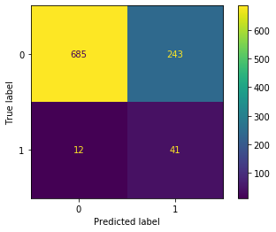

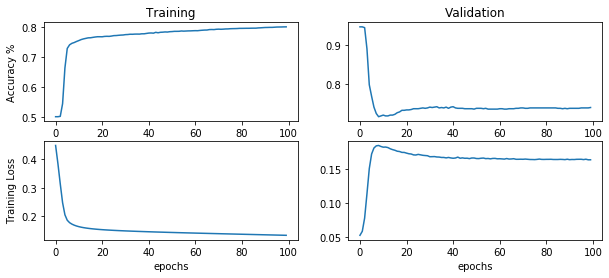

```python
denseUnits = [22,100,50,25,5] #numbers, need at least 1
denseActivation = ['relu','relu','relu','relu','relu'] #sigmoid, relu
finalActivation = 'relu' #sigmoid, relu
mod = makeModel(denseUnits, denseActivation, finalActivation)
optimize = 'adagrad'
iterations = 100
batchSize = 32
runModel(mod, optimize, iterations, batchSize)
```

```
Accuracy: 0.7115188583078491
[[654 274]
 [  9  44]]
              precision    recall  f1-score   support

           0       0.99      0.70      0.82       928
           1       0.14      0.83      0.24        53

    accuracy                           0.71       981
   macro avg       0.56      0.77      0.53       981
weighted avg       0.94      0.71      0.79       981
```

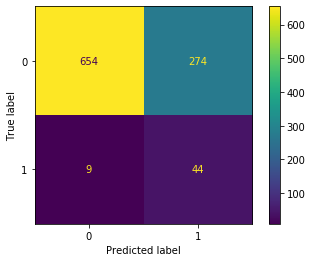

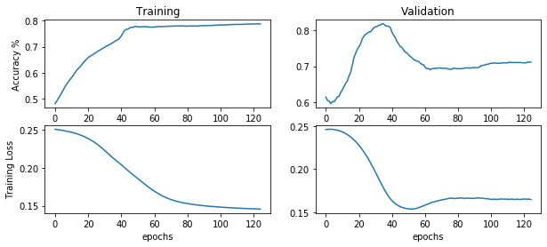

```python
denseUnits = [22,100,50,25,5] #numbers, need at least 1
denseActivation = ['relu','relu','relu','relu','relu'] #sigmoid, relu
finalActivation = 'sigmoid' #sigmoid, relu
mod = makeModel(denseUnits, denseActivation, finalActivation)
optimize = 'adagrad'
iterations = 125
batchSize = 32
runModel(mod, optimize, iterations, batchSize)
```

```
Accuracy: 0.7349643221202854
[[679 249]
 [ 11  42]]
              precision    recall  f1-score   support

           0       0.98      0.73      0.84       928
           1       0.14      0.79      0.24        53

    accuracy                           0.73       981
   macro avg       0.56      0.76      0.54       981
weighted avg       0.94      0.73      0.81       981
```

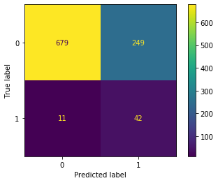

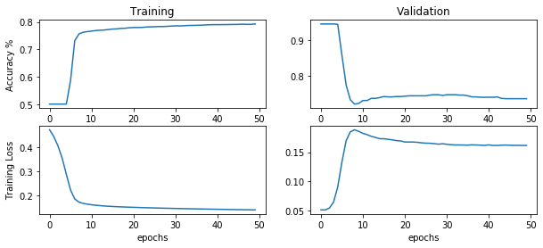

```python
denseUnits = [22,100,50,25,5] #numbers, need at least 1
denseActivation = ['relu','relu','relu','relu','relu'] #sigmoid, relu
finalActivation = 'relu' #sigmoid, relu
mod = makeModel(denseUnits, denseActivation, finalActivation)
optimize = 'adagrad'
iterations = 50
batchSize = 24
runModel(mod, optimize, iterations, batchSize)
```

```
Accuracy: 0.6167176350662589
[[557 371]
 [  5  48]]
              precision    recall  f1-score   support

           0       0.99      0.60      0.75       928
           1       0.11      0.91      0.20        53

    accuracy                           0.62       981
   macro avg       0.55      0.75      0.48       981
weighted avg       0.94      0.62      0.72       981
```

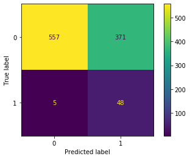

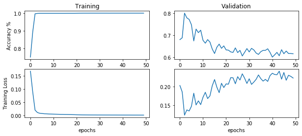

```python
denseUnits = [22,100,50,25,5] #numbers, need at least 1
denseActivation = ['relu','relu','relu','relu','relu'] #sigmoid, relu
finalActivation = 'relu' #sigmoid, relu
mod = makeModel(denseUnits, denseActivation, finalActivation)
optimize = 'rmsprop'
iterations = 50
batchSize = 32
runModel(mod, optimize, iterations, batchSize)
```

Rmsprop seems to do good as it has a much better recall score (although accuracy does drop) and it doesn't need as many epochs in order to reach convergence. Now will test with adam

```
Accuracy: 0.7329255861365953
[[676 252]
 [ 10  43]]
              precision    recall  f1-score   support

           0       0.99      0.73      0.84       928
           1       0.15      0.81      0.25        53

    accuracy                           0.73       981
   macro avg       0.57      0.77      0.54       981
weighted avg       0.94      0.73      0.81       981
```

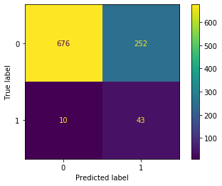

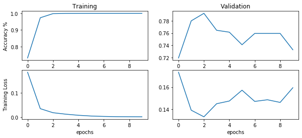

```python
denseUnits = [22,100,50,25,5] #numbers, need at least 1
denseActivation = ['relu','relu','relu','relu','relu'] #sigmoid, relu
finalActivation = 'relu' #sigmoid, relu
mod = makeModel(denseUnits, denseActivation, finalActivation)
optimize = 'adam'
iterations = 10
batchSize = 32
runModel(mod, optimize, iterations, batchSize)
```

Adam seems to do good with the accuracy but the recall score is not as great. Now will test doubling the number of neurons in each dense layer

```
Accuracy: 0.7390417940876657
[[682 246]
 [ 10  43]]
              precision    recall  f1-score   support

           0       0.99      0.73      0.84       928
           1       0.15      0.81      0.25        53

    accuracy                           0.74       981
   macro avg       0.57      0.77      0.55       981
weighted avg       0.94      0.74      0.81       981
```

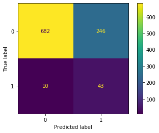

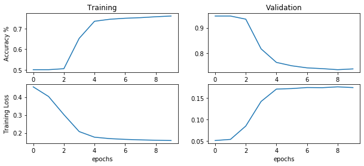

```python
denseUnits = [44,200,100,50,10] #numbers, need at least 1
denseActivation = ['relu','relu','relu','relu','relu'] #sigmoid, relu
finalActivation = 'relu' #sigmoid, relu
mod = makeModel(denseUnits, denseActivation, finalActivation)
optimize = 'adagrad'
iterations = 10
batchSize = 32
runModel(mod, optimize, iterations, batchSize)
```

```
Accuracy: 0.7288481141692151
[[673 255]
 [ 11  42]]
              precision    recall  f1-score   support

           0       0.98      0.73      0.83       928
           1       0.14      0.79      0.24        53

    accuracy                           0.73       981
   macro avg       0.56      0.76      0.54       981
weighted avg       0.94      0.73      0.80       981
```

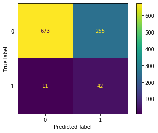

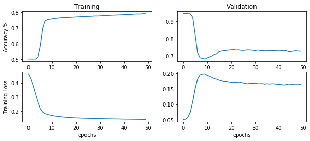

```python
denseUnits = [22,100,50,25,12,10,5] #numbers, need at least 1
denseActivation = ['relu','relu','relu','relu','relu','relu','relu'] #sigmoid, relu
finalActivation = 'relu' #sigmoid, relu
mod = makeModel(denseUnits, denseActivation, finalActivation)
optimize = 'adagrad'
iterations = 50
batchSize = 32
runModel(mod, optimize, iterations, batchSize)
```

Accuracy had a slight drop and recall score slightly dropped too compared to previous run. Now will take 2 layers out

```
Accuracy: 0.744138634046891
[[686 242]
 [  9  44]]
              precision    recall  f1-score   support

           0       0.99      0.74      0.85       928
           1       0.15      0.83      0.26        53

    accuracy                           0.74       981
   macro avg       0.57      0.78      0.55       981
weighted avg       0.94      0.74      0.81       981
```

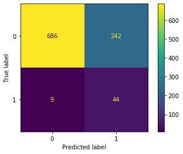

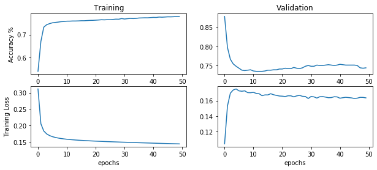

```python
denseUnits = [22,100,50] #numbers, need at least 1
denseActivation = ['relu','relu','relu'] #sigmoid, relu
finalActivation = 'relu' #sigmoid, relu
mod = makeModel(denseUnits, denseActivation, finalActivation)
optimize = 'adagrad'
iterations = 50
batchSize = 32
runModel(mod, optimize, iterations, batchSize)
```

This improved the recall score and accuracy slightly. Now going to try to switch the activations all to sigmoid

```
Accuracy: 0.5127420998980632
[[475 453]
 [ 25  28]]
              precision    recall  f1-score   support

           0       0.95      0.51      0.67       928
           1       0.06      0.53      0.10        53

    accuracy                           0.51       981
   macro avg       0.50      0.52      0.39       981
weighted avg       0.90      0.51      0.63       981
```

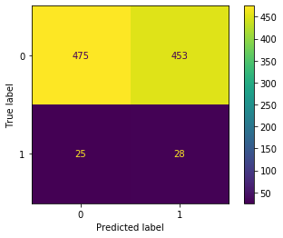

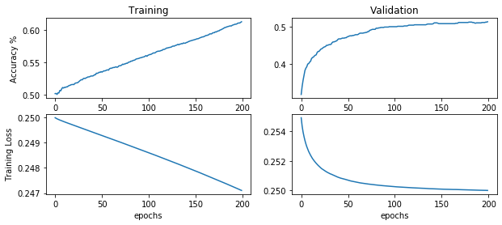

```python
denseUnits = [22,100,50,25,5] #numbers, need at least 1
denseActivation = ['sigmoid','sigmoid','sigmoid','sigmoid','sigmoid'] #sigmoid, relu
finalActivation = 'sigmoid' #sigmoid, relu
mod = makeModel(denseUnits, denseActivation, finalActivation)
optimize = 'adagrad'
iterations = 200
batchSize = 32
runModel(mod, optimize, iterations, batchSize)
```

All sigmoid does not perform very well with a very poor recall score

## Cross Validation with Varying Number of Layers

```python
from sklearn.model_selection import StratifiedKFold
kfold = StratifiedKFold(n_splits=5,shuffle=True, random_state=1).split(X, y)
denseUnits = [100] #numbers, need at least 1
denseActivation = ['relu'] #sigmoid, relu
finalActivation = 'relu' #sigmoid, relu
#mod = makeModel(denseUnits, denseActivation, finalActivation)
optimize = 'adagrad'
iterations = 50
batchSize = 32
#runModel(mod, optimize, iterations, batchSize)

scores = []
recalls = []
for k, (train, test) in enumerate(kfold):
    #print(k,len(train),len(test))
    #Make Model

    # get crossed columns
    X_crossed = X[cross_col_df_names].to_numpy()

    X_train_crossed = X_crossed[train]
    X_test_crossed = X_crossed[test]
    #X_test_crossed = test_X[cross_col_df_names].to_numpy()

    # save categorical features
    X_cat = X[categorical_headers_ints].to_numpy()

    X_train_cat = X_cat[train]
    X_test_cat = X_cat[test]
    #X_test_cat = test_X[categorical_headers_ints].to_numpy()

    # and save off the numeric features
    X_num = X[numeric_headers].to_numpy()

    X_train_num =  X_num[train]
    X_test_num = X_num[test]
    #X_test_num = test_X[numeric_headers].to_numpy()


    # we need to create separate lists for each branch
    crossed_outputs = []

    # CROSSED DATA INPUT
    input_crossed = Input(shape=(X_train_crossed.shape[1],), dtype='int64', name='wide_inputs')
    for idx,col in enumerate(cross_col_df_names):

        # track what the maximum integer value will be for this variable
        # which is the same as the number of categories
        N = max(X[col].max(),test_X[col].max())+1


        # this line of code does this: input_branch[:,idx]
        x = tf.gather(input_crossed, idx, axis=1)

        # now use an embedding to deal with integers as if they were one hot encoded
        x = Embedding(input_dim=N,
                      output_dim=int(np.sqrt(N)),
                      input_length=1, name=col+'_embed')(x)

        # save these outputs to concatenate later
        crossed_outputs.append(x)


    # now concatenate the outputs and add a fully connected layer
    wide_branch = concatenate(crossed_outputs, name='wide_concat')

    # reset this input branch
    all_deep_branch_outputs = []

    # CATEGORICAL DATA INPUT
    input_cat = Input(shape=(X_train_cat.shape[1],), dtype='int64', name='categorical_input')
    for idx,col in enumerate(categorical_headers_ints):

        # track what the maximum integer value will be for this variable
        # which is the same as the number of categories
        N = max(df_train[col].max(),df_test[col].max())+1

        # this line of code does this: input_branch[:,idx]
        x = tf.gather(input_cat, idx, axis=1)

        # now use an embedding to deal with integers as if they were one hot encoded
        x = Embedding(input_dim=N,
                      output_dim=int(np.sqrt(N)),
                      input_length=1, name=col+'_embed')(x)

        # save these outputs to concatenate later
        all_deep_branch_outputs.append(x)

    # NUMERIC DATA INPUT
    # create dense input branch for numeric
    input_num = Input(shape=(X_train_num.shape[1],), name='numeric')
    x_dense = Dense(units=denseUnits[0], activation=denseActivation[0],name='num_1')(input_num)

    all_deep_branch_outputs.append(x_dense)


    # merge the deep branches together
    deep_branch = concatenate(all_deep_branch_outputs,name='concat_embeds')
    for i in range(1, len(denseActivation)):
        deep_branch = Dense(units=denseUnits[i],activation=denseActivation[i], name='deep{}'.format(i))(deep_branch)

    # merge the deep and wide branch
    final_branch = concatenate([wide_branch, deep_branch],
                               name='concat_deep_wide')
    final_branch = Dense(units=1,activation=finalActivation,
                         name='combined')(final_branch)

    model = Model(inputs=[input_crossed,input_cat,input_num],
                  outputs=final_branch)
    #Model Made

    #Now time to run the model
    model.compile(optimizer=optimize,
              loss='mean_squared_error',
              metrics=['accuracy'])

    # lets also add the history variable to see how we are doing
    # and lets add a validation set to keep track of our progress
#     print("Printing y")
#     print(y.unique)
#     print(y_testCV.unique)
    y_trainCV = y[train]
    y_testCV = y[test]
    history = model.fit([X_train_crossed,X_train_cat,X_train_num],
                    y_trainCV,
                    epochs=iterations,
                    batch_size=batchSize,
                    verbose=0,
                    validation_data = ([X_test_crossed,X_test_cat,X_test_num],y_testCV))
#     print(y_testCV.unique)
#     print("Here")
    #yhat = np.round(model.predict(test_X))
    yhat = np.round(model.predict([X_test_crossed,X_test_cat,X_test_num]))
    #print(type(yhat))
    #yhat = np.array(yhat, dtype='int')
    #print(type(yhat))
    #print(yhat)
    #print(type(y_testCV))
    #y_testCV = np.array(y_testCV, dtype='int')
#     print(yhat.unique)
#     print(y_testCV.unique)
#     print(np.unique(yhat))
#     print(np.unique(y_testCV))
    acc_mod = mt.accuracy_score(y_testCV,yhat)
    print("Run Number ", k+1)
    print("Accuracy: " + str(acc_mod))
    #print(mt.confusion_matrix(y_testCV,yhat))
    #print(mt.classification_report(y_testCV,yhat))
    cm = mt.confusion_matrix(y_testCV, yhat, labels=classes)
    recall = cm[1][1]/(cm[1][1]+cm[1][0])
    print("Recall: ", recall)
    recalls.append(recall)
    scores.append(acc_mod)
#     disp = ConfusionMatrixDisplay(confusion_matrix=cm, display_labels=classes)
#     disp.plot()
#     plt.figure(figsize=(10,4))
#     plt.subplot(2,2,1)
#     plt.plot(history.history['accuracy'])

#     plt.ylabel('Accuracy %')
#     plt.title('Training')
#     plt.subplot(2,2,2)
#     plt.plot(history.history['val_accuracy'])
#     plt.title('Validation')

#     plt.subplot(2,2,3)
#     plt.plot(history.history['loss'])
#     plt.ylabel('Training Loss')
#     plt.xlabel('epochs')

#     plt.subplot(2,2,4)
#     plt.plot(history.history['val_loss'])
#     plt.xlabel('epochs')
#     plt.show()



#     pipe_lr.fit(X_train[train], y_train[train])
#     score = pipe_lr.score(X_train[test], y_train[test])
#     scores.append(score)
#     print('Fold: %s, Acc: %.3f' % (k+1, score))

print('\nCV accuracy: %.3f +/- %.3f' % (np.mean(scores), np.std(scores)))
print('\nCV recall: %.3f +/- %.3f' % (np.mean(recalls), np.std(recalls)))
```

```
Run Number  1
Accuracy: 0.7620941020543406
Recall:  0.7933774834437086
Run Number  2
Accuracy: 0.7733598409542743
Recall:  0.7960264900662252
Run Number  3
Accuracy: 0.7567925778661365
Recall:  0.7559681697612732
Run Number  4
Accuracy: 0.7799867461895295
Recall:  0.8395225464190982
Run Number  5
Accuracy: 0.7553050397877984
Recall:  0.7931034482758621

CV accuracy: 0.766 +/- 0.010

CV recall: 0.796 +/- 0.026
```

```python
from sklearn.model_selection import StratifiedKFold
kfold = StratifiedKFold(n_splits=5,shuffle=True, random_state=1).split(X, y)
denseUnits = [22,100,50] #numbers, need at least 1
denseActivation = ['relu','relu','relu'] #sigmoid, relu
finalActivation = 'relu' #sigmoid, relu
optimize = 'adagrad'
iterations = 50
batchSize = 32

scores = []
recalls = []
for k, (train, test) in enumerate(kfold):
    #print(k,len(train),len(test))
    #Make Model

    # get crossed columns
    X_crossed = X[cross_col_df_names].to_numpy()

    X_train_crossed = X_crossed[train]
    X_test_crossed = X_crossed[test]
    #X_test_crossed = test_X[cross_col_df_names].to_numpy()

    # save categorical features
    X_cat = X[categorical_headers_ints].to_numpy()

    X_train_cat = X_cat[train]
    X_test_cat = X_cat[test]
    #X_test_cat = test_X[categorical_headers_ints].to_numpy()

    # and save off the numeric features
    X_num = X[numeric_headers].to_numpy()

    X_train_num =  X_num[train]
    X_test_num = X_num[test]
    #X_test_num = test_X[numeric_headers].to_numpy()


    # we need to create separate lists for each branch
    crossed_outputs = []

    # CROSSED DATA INPUT
    input_crossed = Input(shape=(X_train_crossed.shape[1],), dtype='int64', name='wide_inputs')
    for idx,col in enumerate(cross_col_df_names):

        # track what the maximum integer value will be for this variable
        # which is the same as the number of categories
        N = max(X[col].max(),test_X[col].max())+1


        # this line of code does this: input_branch[:,idx]
        x = tf.gather(input_crossed, idx, axis=1)

        # now use an embedding to deal with integers as if they were one hot encoded
        x = Embedding(input_dim=N,
                      output_dim=int(np.sqrt(N)),
                      input_length=1, name=col+'_embed')(x)

        # save these outputs to concatenate later
        crossed_outputs.append(x)


    # now concatenate the outputs and add a fully connected layer
    wide_branch = concatenate(crossed_outputs, name='wide_concat')

    # reset this input branch
    all_deep_branch_outputs = []

    # CATEGORICAL DATA INPUT
    input_cat = Input(shape=(X_train_cat.shape[1],), dtype='int64', name='categorical_input')
    for idx,col in enumerate(categorical_headers_ints):

        # track what the maximum integer value will be for this variable
        # which is the same as the number of categories
        N = max(df_train[col].max(),df_test[col].max())+1

        # this line of code does this: input_branch[:,idx]
        x = tf.gather(input_cat, idx, axis=1)

        # now use an embedding to deal with integers as if they were one hot encoded
        x = Embedding(input_dim=N,
                      output_dim=int(np.sqrt(N)),
                      input_length=1, name=col+'_embed')(x)

        # save these outputs to concatenate later
        all_deep_branch_outputs.append(x)

    # NUMERIC DATA INPUT
    # create dense input branch for numeric
    input_num = Input(shape=(X_train_num.shape[1],), name='numeric')
    x_dense = Dense(units=denseUnits[0], activation=denseActivation[0],name='num_1')(input_num)

    all_deep_branch_outputs.append(x_dense)


    # merge the deep branches together
    deep_branch = concatenate(all_deep_branch_outputs,name='concat_embeds')
    for i in range(1, len(denseActivation)):
        deep_branch = Dense(units=denseUnits[i],activation=denseActivation[i], name='deep{}'.format(i))(deep_branch)

    # merge the deep and wide branch
    final_branch = concatenate([wide_branch, deep_branch],
                               name='concat_deep_wide')
    final_branch = Dense(units=1,activation=finalActivation,
                         name='combined')(final_branch)

    model = Model(inputs=[input_crossed,input_cat,input_num],
                  outputs=final_branch)
    #Model Made

    #Now time to run the model
    model.compile(optimizer=optimize,
              loss='mean_squared_error',
              metrics=['accuracy'])

    # lets also add the history variable to see how we are doing
    # and lets add a validation set to keep track of our progress
#     print("Printing y")
#     print(y.unique)
#     print(y_testCV.unique)
    y_trainCV = y[train]
    y_testCV = y[test]
    history = model.fit([X_train_crossed,X_train_cat,X_train_num],
                    y_trainCV,
                    epochs=iterations,
                    batch_size=batchSize,
                    verbose=0,
                    validation_data = ([X_test_crossed,X_test_cat,X_test_num],y_testCV))
#     print(y_testCV.unique)
#     print("Here")
    #yhat = np.round(model.predict(test_X))
    yhat = np.round(model.predict([X_test_crossed,X_test_cat,X_test_num]))
    #print(type(yhat))
    #yhat = np.array(yhat, dtype='int')
    #print(type(yhat))
    #print(yhat)
    #print(type(y_testCV))
    #y_testCV = np.array(y_testCV, dtype='int')
#     print(yhat.unique)
#     print(y_testCV.unique)
#     print(np.unique(yhat))
#     print(np.unique(y_testCV))
    acc_mod = mt.accuracy_score(y_testCV,yhat)
    print("Run Number ", k+1)
    print("Accuracy: " + str(acc_mod))
    #print(mt.confusion_matrix(y_testCV,yhat))
    #print(mt.classification_report(y_testCV,yhat))
    cm = mt.confusion_matrix(y_testCV, yhat, labels=classes)
    recall = cm[1][1]/(cm[1][1]+cm[1][0])
    print("Recall: ", recall)
    recalls.append(recall)
    scores.append(acc_mod)
#     disp = ConfusionMatrixDisplay(confusion_matrix=cm, display_labels=classes)
#     disp.plot()
#     plt.figure(figsize=(10,4))
#     plt.subplot(2,2,1)
#     plt.plot(history.history['accuracy'])

#     plt.ylabel('Accuracy %')
#     plt.title('Training')
#     plt.subplot(2,2,2)
#     plt.plot(history.history['val_accuracy'])
#     plt.title('Validation')

#     plt.subplot(2,2,3)
#     plt.plot(history.history['loss'])
#     plt.ylabel('Training Loss')
#     plt.xlabel('epochs')

#     plt.subplot(2,2,4)
#     plt.plot(history.history['val_loss'])
#     plt.xlabel('epochs')
#     plt.show()



#     pipe_lr.fit(X_train[train], y_train[train])
#     score = pipe_lr.score(X_train[test], y_train[test])
#     scores.append(score)
#     print('Fold: %s, Acc: %.3f' % (k+1, score))

print('\nCV accuracy: %.3f +/- %.3f' % (np.mean(scores), np.std(scores)))
print('\nCV recall: %.3f +/- %.3f' % (np.mean(recalls), np.std(recalls)))
```

```
Run Number  1
Accuracy: 0.7693836978131213
Recall:  0.7907284768211921
Run Number  2
Accuracy: 0.7700463883366467
Recall:  0.7880794701986755
Run Number  3
Accuracy: 0.756129887342611
Recall:  0.7639257294429708
Run Number  4
Accuracy: 0.780649436713055
Recall:  0.8567639257294429
Run Number  5
Accuracy: 0.75
Recall:  0.8023872679045093

CV accuracy: 0.765 +/- 0.011

CV recall: 0.800 +/- 0.031
```

```python
from sklearn.model_selection import StratifiedKFold
kfold = StratifiedKFold(n_splits=5,shuffle=True, random_state=1).split(X, y)
denseUnits = [22,100,50,25,5] #numbers, need at least 1
denseActivation = ['relu','relu','relu','relu','relu'] #sigmoid, relu
finalActivation = 'relu' #sigmoid, relu
optimize = 'adagrad'
iterations = 100
batchSize = 32

scores = []
recalls = []
for k, (train, test) in enumerate(kfold):
    #print(k,len(train),len(test))
    #Make Model

    # get crossed columns
    X_crossed = X[cross_col_df_names].to_numpy()

    X_train_crossed = X_crossed[train]
    X_test_crossed = X_crossed[test]
    #X_test_crossed = test_X[cross_col_df_names].to_numpy()

    # save categorical features
    X_cat = X[categorical_headers_ints].to_numpy()

    X_train_cat = X_cat[train]
    X_test_cat = X_cat[test]
    #X_test_cat = test_X[categorical_headers_ints].to_numpy()

    # and save off the numeric features
    X_num = X[numeric_headers].to_numpy()

    X_train_num =  X_num[train]
    X_test_num = X_num[test]
    #X_test_num = test_X[numeric_headers].to_numpy()


    # we need to create separate lists for each branch
    crossed_outputs = []

    # CROSSED DATA INPUT
    input_crossed = Input(shape=(X_train_crossed.shape[1],), dtype='int64', name='wide_inputs')
    for idx,col in enumerate(cross_col_df_names):

        # track what the maximum integer value will be for this variable
        # which is the same as the number of categories
        N = max(X[col].max(),test_X[col].max())+1


        # this line of code does this: input_branch[:,idx]
        x = tf.gather(input_crossed, idx, axis=1)

        # now use an embedding to deal with integers as if they were one hot encoded
        x = Embedding(input_dim=N,
                      output_dim=int(np.sqrt(N)),
                      input_length=1, name=col+'_embed')(x)

        # save these outputs to concatenate later
        crossed_outputs.append(x)


    # now concatenate the outputs and add a fully connected layer
    wide_branch = concatenate(crossed_outputs, name='wide_concat')

    # reset this input branch
    all_deep_branch_outputs = []

    # CATEGORICAL DATA INPUT
    input_cat = Input(shape=(X_train_cat.shape[1],), dtype='int64', name='categorical_input')
    for idx,col in enumerate(categorical_headers_ints):

        # track what the maximum integer value will be for this variable
        # which is the same as the number of categories
        N = max(df_train[col].max(),df_test[col].max())+1

        # this line of code does this: input_branch[:,idx]
        x = tf.gather(input_cat, idx, axis=1)

        # now use an embedding to deal with integers as if they were one hot encoded
        x = Embedding(input_dim=N,
                      output_dim=int(np.sqrt(N)),
                      input_length=1, name=col+'_embed')(x)

        # save these outputs to concatenate later
        all_deep_branch_outputs.append(x)

    # NUMERIC DATA INPUT
    # create dense input branch for numeric
    input_num = Input(shape=(X_train_num.shape[1],), name='numeric')
    x_dense = Dense(units=denseUnits[0], activation=denseActivation[0],name='num_1')(input_num)

    all_deep_branch_outputs.append(x_dense)


    # merge the deep branches together
    deep_branch = concatenate(all_deep_branch_outputs,name='concat_embeds')
    for i in range(1, len(denseActivation)):
        deep_branch = Dense(units=denseUnits[i],activation=denseActivation[i], name='deep{}'.format(i))(deep_branch)

    # merge the deep and wide branch
    final_branch = concatenate([wide_branch, deep_branch],
                               name='concat_deep_wide')
    final_branch = Dense(units=1,activation=finalActivation,
                         name='combined')(final_branch)

    model = Model(inputs=[input_crossed,input_cat,input_num],
                  outputs=final_branch)
    #Model Made

    #Now time to run the model
    model.compile(optimizer=optimize,
              loss='mean_squared_error',
              metrics=['accuracy'])

    # lets also add the history variable to see how we are doing
    # and lets add a validation set to keep track of our progress
#     print("Printing y")
#     print(y.unique)
#     print(y_testCV.unique)
    y_trainCV = y[train]
    y_testCV = y[test]
    history = model.fit([X_train_crossed,X_train_cat,X_train_num],
                    y_trainCV,
                    epochs=iterations,
                    batch_size=batchSize,
                    verbose=0,
                    validation_data = ([X_test_crossed,X_test_cat,X_test_num],y_testCV))
#     print(y_testCV.unique)
#     print("Here")
    #yhat = np.round(model.predict(test_X))
    yhat = np.round(model.predict([X_test_crossed,X_test_cat,X_test_num]))
    #print(type(yhat))
    #yhat = np.array(yhat, dtype='int')
    #print(type(yhat))
    #print(yhat)
    #print(type(y_testCV))
    #y_testCV = np.array(y_testCV, dtype='int')
#     print(yhat.unique)
#     print(y_testCV.unique)
#     print(np.unique(yhat))
#     print(np.unique(y_testCV))
    acc_mod = mt.accuracy_score(y_testCV,yhat)
    print("Run Number ", k+1)
    print("Accuracy: " + str(acc_mod))
    #print(mt.confusion_matrix(y_testCV,yhat))
    #print(mt.classification_report(y_testCV,yhat))
    cm = mt.confusion_matrix(y_testCV, yhat, labels=classes)
    recall = cm[1][1]/(cm[1][1]+cm[1][0])
    print("Recall: ", recall)
    recalls.append(recall)
    scores.append(acc_mod)
#     disp = ConfusionMatrixDisplay(confusion_matrix=cm, display_labels=classes)
#     disp.plot()
#     plt.figure(figsize=(10,4))
#     plt.subplot(2,2,1)
#     plt.plot(history.history['accuracy'])

#     plt.ylabel('Accuracy %')
#     plt.title('Training')
#     plt.subplot(2,2,2)
#     plt.plot(history.history['val_accuracy'])
#     plt.title('Validation')

#     plt.subplot(2,2,3)
#     plt.plot(history.history['loss'])
#     plt.ylabel('Training Loss')
#     plt.xlabel('epochs')

#     plt.subplot(2,2,4)
#     plt.plot(history.history['val_loss'])
#     plt.xlabel('epochs')
#     plt.show()



#     pipe_lr.fit(X_train[train], y_train[train])
#     score = pipe_lr.score(X_train[test], y_train[test])
#     scores.append(score)
#     print('Fold: %s, Acc: %.3f' % (k+1, score))

print('\nCV accuracy: %.3f +/- %.3f' % (np.mean(scores), np.std(scores)))
print('\nCV recall: %.3f +/- %.3f' % (np.mean(recalls), np.std(recalls)))
```

```
Run Number  1
Accuracy: 0.7693836978131213
Recall:  0.8172185430463577
Run Number  2
Accuracy: 0.7859509609012592
Recall:  0.8158940397350993
Run Number  3
Accuracy: 0.7753479125248509
Recall:  0.8103448275862069
Run Number  4
Accuracy: 0.7813121272365805
Recall:  0.8342175066312998
Run Number  5
Accuracy: 0.7446949602122016
Recall:  0.7904509283819628

CV accuracy: 0.771 +/- 0.014

CV recall: 0.814 +/- 0.014
```

```python
from sklearn.model_selection import StratifiedKFold
kfold = StratifiedKFold(n_splits=5,shuffle=True, random_state=1).split(X, y)
denseUnits = [22,100,50,25,12,10,5] #numbers, need at least 1
denseActivation = ['relu','relu','relu','relu','relu','relu','relu'] #sigmoid, relu
finalActivation = 'relu' #sigmoid, relu
optimize = 'adagrad'
iterations = 50
batchSize = 32

scores = []
recalls = []
for k, (train, test) in enumerate(kfold):
    #print(k,len(train),len(test))
    #Make Model

    # get crossed columns
    X_crossed = X[cross_col_df_names].to_numpy()

    X_train_crossed = X_crossed[train]
    X_test_crossed = X_crossed[test]
    #X_test_crossed = test_X[cross_col_df_names].to_numpy()

    # save categorical features
    X_cat = X[categorical_headers_ints].to_numpy()

    X_train_cat = X_cat[train]
    X_test_cat = X_cat[test]
    #X_test_cat = test_X[categorical_headers_ints].to_numpy()

    # and save off the numeric features
    X_num = X[numeric_headers].to_numpy()

    X_train_num =  X_num[train]
    X_test_num = X_num[test]
    #X_test_num = test_X[numeric_headers].to_numpy()


    # we need to create separate lists for each branch
    crossed_outputs = []

    # CROSSED DATA INPUT
    input_crossed = Input(shape=(X_train_crossed.shape[1],), dtype='int64', name='wide_inputs')
    for idx,col in enumerate(cross_col_df_names):

        # track what the maximum integer value will be for this variable
        # which is the same as the number of categories
        N = max(X[col].max(),test_X[col].max())+1


        # this line of code does this: input_branch[:,idx]
        x = tf.gather(input_crossed, idx, axis=1)

        # now use an embedding to deal with integers as if they were one hot encoded
        x = Embedding(input_dim=N,
                      output_dim=int(np.sqrt(N)),
                      input_length=1, name=col+'_embed')(x)

        # save these outputs to concatenate later
        crossed_outputs.append(x)


    # now concatenate the outputs and add a fully connected layer
    wide_branch = concatenate(crossed_outputs, name='wide_concat')

    # reset this input branch
    all_deep_branch_outputs = []

    # CATEGORICAL DATA INPUT
    input_cat = Input(shape=(X_train_cat.shape[1],), dtype='int64', name='categorical_input')
    for idx,col in enumerate(categorical_headers_ints):

        # track what the maximum integer value will be for this variable
        # which is the same as the number of categories
        N = max(df_train[col].max(),df_test[col].max())+1

        # this line of code does this: input_branch[:,idx]
        x = tf.gather(input_cat, idx, axis=1)

        # now use an embedding to deal with integers as if they were one hot encoded
        x = Embedding(input_dim=N,
                      output_dim=int(np.sqrt(N)),
                      input_length=1, name=col+'_embed')(x)

        # save these outputs to concatenate later
        all_deep_branch_outputs.append(x)

    # NUMERIC DATA INPUT
    # create dense input branch for numeric
    input_num = Input(shape=(X_train_num.shape[1],), name='numeric')
    x_dense = Dense(units=denseUnits[0], activation=denseActivation[0],name='num_1')(input_num)

    all_deep_branch_outputs.append(x_dense)


    # merge the deep branches together
    deep_branch = concatenate(all_deep_branch_outputs,name='concat_embeds')
    for i in range(1, len(denseActivation)):
        deep_branch = Dense(units=denseUnits[i],activation=denseActivation[i], name='deep{}'.format(i))(deep_branch)

    # merge the deep and wide branch
    final_branch = concatenate([wide_branch, deep_branch],
                               name='concat_deep_wide')
    final_branch = Dense(units=1,activation=finalActivation,
                         name='combined')(final_branch)

    model = Model(inputs=[input_crossed,input_cat,input_num],
                  outputs=final_branch)
    #Model Made

    #Now time to run the model
    model.compile(optimizer=optimize,
              loss='mean_squared_error',
              metrics=['accuracy'])

    # lets also add the history variable to see how we are doing
    # and lets add a validation set to keep track of our progress
#     print("Printing y")
#     print(y.unique)
#     print(y_testCV.unique)
    y_trainCV = y[train]
    y_testCV = y[test]
    history = model.fit([X_train_crossed,X_train_cat,X_train_num],
                    y_trainCV,
                    epochs=iterations,
                    batch_size=batchSize,
                    verbose=0,
                    validation_data = ([X_test_crossed,X_test_cat,X_test_num],y_testCV))
#     print(y_testCV.unique)
#     print("Here")
    #yhat = np.round(model.predict(test_X))
    yhat = np.round(model.predict([X_test_crossed,X_test_cat,X_test_num]))
    #print(type(yhat))
    #yhat = np.array(yhat, dtype='int')
    #print(type(yhat))
    #print(yhat)
    #print(type(y_testCV))
    #y_testCV = np.array(y_testCV, dtype='int')
#     print(yhat.unique)
#     print(y_testCV.unique)
#     print(np.unique(yhat))
#     print(np.unique(y_testCV))
    acc_mod = mt.accuracy_score(y_testCV,yhat)
    print("Run Number ", k+1)
    print("Accuracy: " + str(acc_mod))
    #print(mt.confusion_matrix(y_testCV,yhat))
    #print(mt.classification_report(y_testCV,yhat))
    cm = mt.confusion_matrix(y_testCV, yhat, labels=classes)
    recall = cm[1][1]/(cm[1][1]+cm[1][0])
    print("Recall: ", recall)
    recalls.append(recall)
    scores.append(acc_mod)
#     disp = ConfusionMatrixDisplay(confusion_matrix=cm, display_labels=classes)
#     disp.plot()
#     plt.figure(figsize=(10,4))
#     plt.subplot(2,2,1)
#     plt.plot(history.history['accuracy'])

#     plt.ylabel('Accuracy %')
#     plt.title('Training')
#     plt.subplot(2,2,2)
#     plt.plot(history.history['val_accuracy'])
#     plt.title('Validation')

#     plt.subplot(2,2,3)
#     plt.plot(history.history['loss'])
#     plt.ylabel('Training Loss')
#     plt.xlabel('epochs')

#     plt.subplot(2,2,4)
#     plt.plot(history.history['val_loss'])
#     plt.xlabel('epochs')
#     plt.show()



#     pipe_lr.fit(X_train[train], y_train[train])
#     score = pipe_lr.score(X_train[test], y_train[test])
#     scores.append(score)
#     print('Fold: %s, Acc: %.3f' % (k+1, score))

print('\nCV accuracy: %.3f +/- %.3f' % (np.mean(scores), np.std(scores)))
print('\nCV recall: %.3f +/- %.3f' % (np.mean(recalls), np.std(recalls)))
```

```
Run Number  1
Accuracy: 0.7680583167660703
Recall:  0.8450331125827815
Run Number  2
Accuracy: 0.7799867461895295
Recall:  0.8119205298013245
Run Number  3
Accuracy: 0.7640821736249171
Recall:  0.8063660477453581
Run Number  4
Accuracy: 0.7720344599072233
Recall:  0.8381962864721485
Run Number  5
Accuracy: 0.7539787798408488
Recall:  0.8222811671087533

CV accuracy: 0.768 +/- 0.009

CV recall: 0.825 +/- 0.015
```

In looking at these 4 different runs of cross validation, the last run (the one with the most layers) turned out to have the best performance. Although it didn't have the highest accuracy of all the models, this model ended up with the highest recall score and its accuracy was close enough to the other models such that it wouldn't detract from its performance by that much.

## Compare to MLP

```python
# get crossed columns
X_train_crossed = X[cross_col_df_names].to_numpy()
X_test_crossed = test_X[cross_col_df_names].to_numpy()

# save categorical features
X_train_cat = X[categorical_headers_ints].to_numpy()
X_test_cat = test_X[categorical_headers_ints].to_numpy()

# and save off the numeric features
X_train_num =  X[numeric_headers].to_numpy()
X_test_num = test_X[numeric_headers].to_numpy()

classes = [0,1]
```

Going to do one run on the NN that performed the best and then use this for comparisons to the MLP

```
Accuracy: 0.7604485219164119
[[705 223]
 [ 12  41]]
              precision    recall  f1-score   support

           0       0.98      0.76      0.86       928
           1       0.16      0.77      0.26        53

    accuracy                           0.76       981
   macro avg       0.57      0.77      0.56       981
weighted avg       0.94      0.76      0.82       981
```

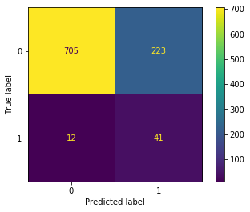

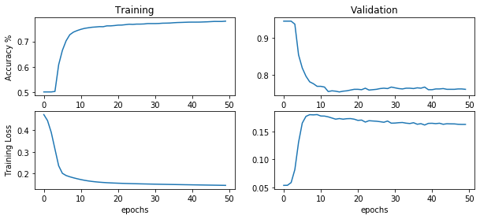

```python
denseUnits = [22,100,50,25,12,10,5] #numbers, need at least 1
denseActivation = ['relu','relu','relu','relu','relu','relu','relu'] #sigmoid, relu
finalActivation = 'relu' #sigmoid, relu
optimize = 'adagrad'
iterations = 50
batchSize = 32
mod = makeModel(denseUnits, denseActivation, finalActivation)
nn_test, yhat = runModel(mod, optimize, iterations, batchSize)
```

Time to run the MLP on the data set

```python
#Going to drop the crossed columns for the training and testing data
X_mlp = X.drop(['hypertension_heart_disease_smoking_status_int','ever_married_work_type_int_gender', 'bmi_range_int_heart_disease','bmi_range_int_gender'], axis=1)
test_X_mlp = test_X.drop(['hypertension_heart_disease_smoking_status_int','ever_married_work_type_int_gender', 'bmi_range_int_heart_disease','bmi_range_int_gender'], axis=1)
```

```python
from tensorflow.keras.models import Sequential
# make a 3 layer keras MLP
mlp = Sequential()
mlp.add( Flatten() ) # make images flat for the MLP input
mlp.add( Dense(input_dim=X_mlp.shape[1], units=30,
               activation='relu') )
mlp.add( Dense(units=15, activation='relu') )
mlp.add( Dense(2) )
mlp.add( Activation('relu') )

mlp.compile(loss='mean_squared_error',
              optimizer='adagrad',
              metrics=['accuracy'])

history = mlp.fit(X_mlp, y,
        batch_size=32, epochs=100,
        shuffle=True, verbose=0,
                 validation_data = (test_X_mlp,y_test))
```

```
Accuracy: 0.8205912334352702
[[778 150]
 [ 26  27]]
              precision    recall  f1-score   support

           0       0.97      0.84      0.90       928
           1       0.15      0.51      0.23        53

    accuracy                           0.82       981
   macro avg       0.56      0.67      0.57       981
weighted avg       0.92      0.82      0.86       981
```

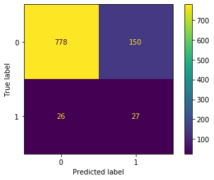

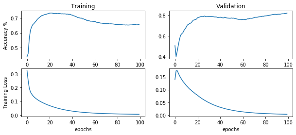

```python
#yhat_mlp = np.argmax(mlp.predict(X_test), axis=1)
yhat_mlp = np.argmax(mlp.predict(test_X_mlp), axis=1)
#yhat_mlp = np.round(mlp.predict([X_test_crossed,X_test_cat,X_test_num]), axis=1)
acc_mlp = mt.accuracy_score(y_test,yhat_mlp)
print("Accuracy: " + str(acc_mlp))
print(mt.confusion_matrix(y_test,yhat_mlp))
print(mt.classification_report(y_test,yhat_mlp))
cm = mt.confusion_matrix(y_test, yhat_mlp, labels=classes)
mlp_test = cm
disp = ConfusionMatrixDisplay(confusion_matrix=cm, display_labels=classes)
disp.plot()

plt.figure(figsize=(10,4))
plt.subplot(2,2,1)
plt.plot(history.history['accuracy'])

plt.ylabel('Accuracy %')
plt.title('Training')
plt.subplot(2,2,2)
plt.plot(history.history['val_accuracy'])
plt.title('Validation')

plt.subplot(2,2,3)
plt.plot(history.history['loss'])
plt.ylabel('Training Loss')
plt.xlabel('epochs')

plt.subplot(2,2,4)
plt.plot(history.history['val_loss'])
plt.xlabel('epochs')
```

Going to run the McNemar test comparing the NN vs. the MLP now

```python
# Example of calculating the mcnemar test
from statsmodels.stats.contingency_tables import mcnemar
# define contingency table
table = [[nn_test[1][1], nn_test[1][0]],[mlp_test[1][1], mlp_test[1][0]]]
# calculate mcnemar test
result = mcnemar(table, exact=True)
# summarize the finding
print('statistic=%.3f, p-value=%.1f' % (result.statistic, result.pvalue))
# interpret the p-value
alpha = 0.05
if result.pvalue > alpha:
    print("Same proportions of errors (don't reject H0)")
else:
    print('Different proportions of errors (reject H0)')
```

```
statistic=12.000, p-value=0.0
Different proportions of errors (reject H0)
```

```python
# Example of calculating the mcnemar test
from statsmodels.stats.contingency_tables import mcnemar
# define contingency table
table = [[nn_test[1][1] + nn_test[0][0], nn_test[1][0] + nn_test[0][1]],[mlp_test[1][1] + mlp_test[0][0], mlp_test[1][0] + mlp_test[0][1]]]
# calculate mcnemar test
result = mcnemar(table, exact=True)
# summarize the finding
print('statistic=%.3f, p-value=%.1f' % (result.statistic, result.pvalue))
# interpret the p-value
alpha = 0.05
if result.pvalue > alpha:
    print("Same proportions of errors (don't reject H0)")
else:
    print('Different proportions of errors (reject H0)')
```

```
statistic=235.000, p-value=0.0
Different proportions of errors (reject H0)
```

Source: https://machinelearningmastery.com/mcnemars-test-for-machine-learning/

Going to plot the Area Under the Curve of a Receiver Operating Characteristic curve next

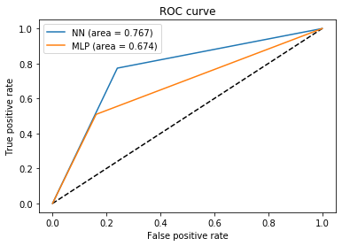

```python
from sklearn.metrics import roc_curve
from sklearn.metrics import auc
fpr_nn, tpr_nn, thresholds_nn = roc_curve(y_test, yhat)
fpr_mlp, tpr_mlp, thresholds_mlp = roc_curve(y_test, yhat_mlp)
auc_nn = auc(fpr_nn, tpr_nn)
auc_mlp = auc(fpr_mlp, tpr_mlp)
plt.figure(1)
plt.plot([0, 1], [0, 1], 'k--')
plt.plot(fpr_nn, tpr_nn, label='NN (area = {:.3f})'.format(auc_nn))
plt.plot(fpr_mlp, tpr_mlp, label='MLP (area = {:.3f})'.format(auc_mlp))
plt.xlabel('False positive rate')
plt.ylabel('True positive rate')
plt.title('ROC curve')
plt.legend(loc='best')
plt.show()
```

Source: https://www.sciencedirect.com/science/article/pii/S1556086415306043

Source 2: https://www.dlology.com/blog/simple-guide-on-how-to-generate-roc-plot-for-keras-classifier/

Going to run cross validation on MLP below too

```python
#Cross Validation for MLP

from sklearn.model_selection import StratifiedKFold
kfold = StratifiedKFold(n_splits=5,shuffle=True, random_state=1).split(X_mlp, y)

scores = []
recalls = []
for k, (train, test) in enumerate(kfold):
    X_mlp_num = X_mlp.to_numpy()
    y_mlp_num = y.to_numpy()

    X_mlp_train = X_mlp_num[train]
    y_mlp_train = y_mlp_num[train]
    X_mlp_test = X_mlp_num[test]
    y_mlp_test = y_mlp_num[test]
    mlp = Sequential()
    mlp.add( Flatten() ) # make images flat for the MLP input
    mlp.add( Dense(input_dim=X_mlp_train.shape[1], units=30,
                   activation='relu') )
    mlp.add( Dense(units=15, activation='relu') )
    mlp.add( Dense(2) )
    mlp.add( Activation('relu') )

    mlp.compile(loss='mean_squared_error',
                  optimizer='adagrad',
                  metrics=['accuracy'])

    mlp.fit(X_mlp_train, y_mlp_train,
            batch_size=32, epochs=100,
            shuffle=True, verbose=0)

    yhat_mlp = np.argmax(mlp.predict(X_mlp_test), axis=1)
    acc_mlp = mt.accuracy_score(y_mlp_test,yhat_mlp)
    cm = mt.confusion_matrix(y_mlp_test, yhat_mlp, labels=classes)

    print("Run Number ", k+1)
    print("Accuracy: " + str(acc_mlp))
    recall = cm[1][1]/(cm[1][1]+cm[1][0])
    print("Recall: ", recall)
    recalls.append(recall)
    scores.append(acc_mod)

print('\nCV accuracy: %.3f +/- %.3f' % (np.mean(scores), np.std(scores)))
print('\nCV recall: %.3f +/- %.3f' % (np.mean(recalls), np.std(recalls)))
```

```
Run Number  1
Accuracy: 0.7687210072895958
Recall:  0.6079470198675496
Run Number  2
Accuracy: 0.7203445990722332
Recall:  0.5483443708609271
Run Number  3
Accuracy: 0.7163684559310802
Recall:  0.5344827586206896
Run Number  4
Accuracy: 0.6368455931080186
Recall:  0.4907161803713528
Run Number  5
Accuracy: 0.656498673740053
Recall:  0.5358090185676393

CV accuracy: 0.750 +/- 0.000

CV recall: 0.543 +/- 0.038
```

The 5-fold stratified cross validation being run on the MLP indicates that the NN is much better for this case. In its cross validation (ran in the section before), the NN had a recall score average of 0.825 +/- 0.015. On the other hand, the MLP has a recall score average of 0.543 +/- 0.038.

## Exceptional Work

For this part we will create a model with Embedding layers, capture the weights of the first layer after the Embedding and cross multipy it with corresponding training dataset, then use sklearn's t-distributed Stochastic Neighbor Embedding (TSNE) to do dimentionality reduction and try to visualize the results.

```python
X_train_cat = X[categorical_headers_ints].to_numpy()

# and save off the numeric features
X_train_num =  X[numeric_headers].to_numpy()

all_branch_outputs = [] # this is where we will keep track of output of each branch

input_cat = Input(shape=(X_train_cat.shape[1],), dtype='int64', name='categorical')
for idx,col in enumerate(categorical_headers_ints):

    # track what the maximum integer value will be for this variable
    # which is the same as the number of categories
    N = max(df_train[col].max(),df_test[col].max())+1


    # this line of code does this: input_branch[:,idx]
    x = tf.gather(input_cat, idx, axis=1)

    # now use an embedding to deal with integers as if they were one hot encoded
    x = Embedding(input_dim=N,
                  output_dim=int(np.sqrt(N)),
                  input_length=1, name=col+'_embed')(x)

    # save these outputs to concatenate later
    all_branch_outputs.append(x)

# HERE IS THE ADDING OF AN INPUT USING NUMERIC DATA
# create dense input branch for numeric
inputs_num = Input(shape=(X_train_num.shape[1],), name='numeric')
x_dense = Dense(units=22, activation='relu', name='num_1')(inputs_num)

all_branch_outputs.append(x_dense)

# now concatenate the outputs and add a fully connected layer
final_branch = concatenate(all_branch_outputs, name='concat_1')
final_branch = Dense(units=6, activation='relu', name='combined_1')(final_branch)
final_branch = Dense(units=1, activation='sigmoid', name='combined_2')(final_branch)

model = Model(inputs=[input_cat,inputs_num], outputs=final_branch)

model.compile(optimizer='sgd',
              loss='mean_squared_error',
              metrics=['accuracy'])
model.summary()
```

```
Model: "model_102"
__________________________________________________________________________________________________
Layer (type)                    Output Shape         Param #     Connected to
==================================================================================================
categorical (InputLayer)        [(None, 3)]          0
__________________________________________________________________________________________________
tf.compat.v1.gather_707 (TFOpLa (None,)              0           categorical[0][0]
__________________________________________________________________________________________________
tf.compat.v1.gather_708 (TFOpLa (None,)              0           categorical[0][0]
__________________________________________________________________________________________________
tf.compat.v1.gather_709 (TFOpLa (None,)              0           categorical[0][0]
__________________________________________________________________________________________________
numeric (InputLayer)            [(None, 3)]          0
__________________________________________________________________________________________________
work_type_int_embed (Embedding) (None, 2)            10          tf.compat.v1.gather_707[0][0]
__________________________________________________________________________________________________
smoking_status_int_embed (Embed (None, 2)            8           tf.compat.v1.gather_708[0][0]
__________________________________________________________________________________________________
bmi_range_int_embed (Embedding) (None, 2)            8           tf.compat.v1.gather_709[0][0]
__________________________________________________________________________________________________
num_1 (Dense)                   (None, 22)           88          numeric[0][0]
__________________________________________________________________________________________________
concat_1 (Concatenate)          (None, 28)           0           work_type_int_embed[0][0]
                                                                 smoking_status_int_embed[0][0]
                                                                 bmi_range_int_embed[0][0]
                                                                 num_1[0][0]
__________________________________________________________________________________________________
combined_1 (Dense)              (None, 6)            174         concat_1[0][0]
__________________________________________________________________________________________________
combined_2 (Dense)              (None, 1)            7           combined_1[0][0]
==================================================================================================
Total params: 295
Trainable params: 295
Non-trainable params: 0
__________________________________________________________________________________________________
```

```python
embd_weights = model.get_weights()[5]
newX = np.hstack((X_train_cat,X_train_num))
newX.shape
```

```
(7544, 6)
```

```python
embd_weights = newX @ embd_weights.T
embd_weights.shape
```

```
(7544, 28)
```

```python
from sklearn.manifold import TSNE
embd_reduced = TSNE(n_components=2).fit_transform(embd_weights)
embd_reduced.shape
```

```
(7544, 2)
```

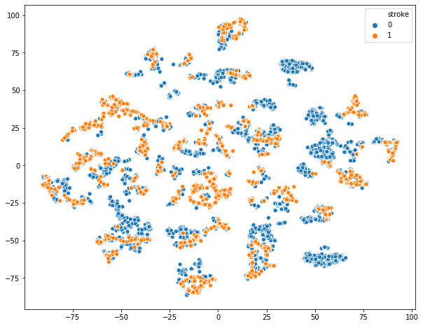

```python
plt.figure(figsize=(10,8))
sns.scatterplot(embd_reduced[:,0], embd_reduced[:,1],
                hue=y)

#Source: https://blog.dataiku.com/deep-beers-visualizing-embeddings-of-keras-recommendation-engines
```

From the scatter block we can see lots of cluster of points for stroke and no-stroke. We can see bigger clusters of no stroke in quadrants 2, 3, and 4 (bottom left, top right, and bottom right). The stroke clusters are evenly distributed over the plot. However, there's overlap in almost all the clusters, so we can't effectively differentiate between the two classes.

Now we will try doing the same process on our MLP model and see how different the plot will be. For the MLP, we will capture the weights of the first layer.

```python
weights_mlp = mlp.get_weights()[0]
print(X_mlp.shape)
print(weights_mlp.shape)

weights_mlp = X_mlp @ weights_mlp
weights_mlp.shape
```

```
(7544, 12)
(12, 30)
```

```
(7544, 30)
```

```python
from sklearn.manifold import TSNE
embd_reduced2 = TSNE(n_components=2).fit_transform(weights_mlp)
embd_reduced2.shape
```

```
(7544, 2)
```

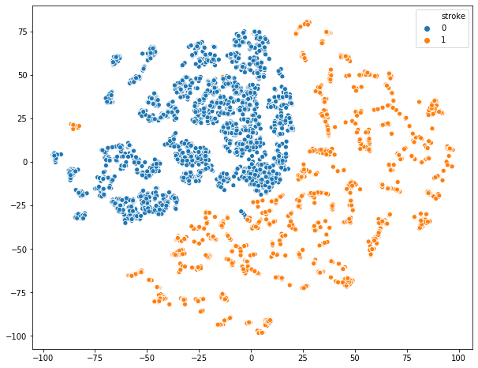

```python
plt.figure(figsize=(10,8))
sns.scatterplot(embd_reduced2[:,0], embd_reduced2[:,1],
                legend='full',hue=y)
```

We can see in this plot clear grouping of the different classes, the two classes do not overlap and we can easily differentiate them in this plot over the other. Also the clusters are denser in class no-stroke than in class stroke. One similarity between the two classes, is that class no-stroke exist at smaller values of dimension 1 and larger values of dimension 2. The clusters of no-stroke appear to take uo the 1st quadrant (top left) of the visual. However, clusters of class stroke appear to exist in quadrants 2, 3, and 4 (bottom left, top right, and bottom right). The values of the dimensions for strokes seem to be proportional. For example, strokes exist where both dimensions take on smaller values. Then, as dimension 1 increases, the value for dimension 2 also increases for where strokes exist.